# Ejercicios Visualización Datos

Excel es un gran programa para visualizar y manipular pequeños conjuntos de datos. Sin embargo, no es excelente para trabajar con conjuntos grandes de datos y los gráficos resultantes generalmente no se pueden publicar. Aprender R y los paquetes de graficación es una excelente manera de generar figuras publicables de manera reproducible. El uso de R no sólo evitará que edites tus datos accidentalmente, sino que también te permitirá generar scripts que se pueden ver más tarde o reutilizar para generar el mismo gráfico usando datos diferentes. Esto evitará que tengas que confiar en tu memoria cuando te preguntes qué datos se utilizaron o cómo se generó un gráfico.

Vamos a importar y revisar unos datos que se encuentran en formato excel. Es posible que necesites instalar el paquete **readxl** para el siguiente ejercicio.

```r
list.of.packages = c("readxl","ggplot2")
list.of.packages
```

```
[1] "readxl"  "ggplot2"
```

```r
new.packages = list.of.packages[!(list.of.packages %in% installed.packages())]
if(length(new.packages)> 0) install.packages(new.packages)

invisible(lapply(list.of.packages, FUN=library, character.only=TRUE))
```

Revisar la función **read_xlsx()** que nos permitirá importar los datos de la hoja excel a un objeto de tipo tibble.

```r
data = readxl::read_xlsx(
  "RNASeq_totalcounts_vs_totaltrans.xlsx",sheet=1)
```

```r
datasrst
```

[output not shown]

Un tibble, o tbl_df, es una reinvención moderna del data.frame, manteniendo lo que el tiempo ha demostrado ser efectivo y descartando lo que no lo es. Los tibbles son data.frames que hacen menos (por ejemplo, no cambian los nombres o tipos de variables) y se quejan más (por ejemplo, cuando una variable no existe). Esto nos obliga a afrontar los problemas antes, lo que normalmente conduce a un código más limpio y documentado.

Estos datos incluyen el recuento total de lecturas de transcripciones sumado por muestra y el número total de transcripciones recuperadas por muestra que tuvieron al menos 100 lecturas. Estos datos se derivan de un experimento de RNAseq en masa descrito por [Himes et al. (2014)](https://pubmed.ncbi.nlm.nih.gov/24926665/). En el experimento, los autores “caracterizaron cambios transcriptómicos en cuatro líneas celulares primarias de ASM humanas que fueron tratadas con dexametasona”, una terapia común para el asma. Cada línea celular incluía un control negativo tratado y no tratado, lo que dio como resultado un tamaño de muestra total de 8.

Observemos en los datos como están identificadas las columnas de la estructura de datos.

```r
colnames(data)
```

```
[1] "Sample Name"           "Treatment"             "Number of Transcripts" "Total Counts"
```

Los espacios causan problemas en la manipulación de datos en R, pero podemos indicar en los argumentos de carga para que repare los nombres de nuestras columnas.

```r
data=readxl::read_xlsx(
  "RNASeq_totalcounts_vs_totaltrans.xlsx",sheet=1, .name_repair="universal")
```

```r
colnames(data)
```

```
[1] "Sample.Name"           "Treatment"             "Number.of.Transcripts" "Total.Counts"
```

El valor predeterminado de Readxl es **.name_repair = “unique”**, lo que garantiza que cada columna tenga un nombre único. Si eso ya es cierto para los nombres de las columnas, readxl no los tocará.

El valor **.name_repair = “universal”** se asegura de que no contengan caracteres prohibidos ni palabras reservadas.

¿Cuál es la relación entre las sumas totales de transcripciones por muestra y el número de transcripciones recuperadas por muestra?

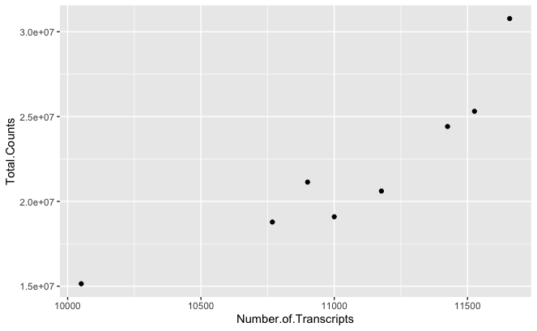

```r
ggplot(data=data, mapping= aes(x=Number.of.Transcripts, y = Total.Counts)) +
        geom_point()
```

Podemos ver que existe una relación entre el número de transcripciones por muestra y el total de transcripciones recuperadas por muestra. Los parámetros predeterminados de ggplot2 son excelentes para el análisis de datos exploratorios.

Hay múltiples funciones geom que cambian el tipo de básico de gráfico o aspectos de la representación. Podemos crear diagramas de dispersión (geom_point()), diagramas de líneas (geom_line(),geom_path()), diagramas de barras (geom_bar(), geom_col()), líneas modeladas a datos ajustados (geom_smooth()), mapas de calor (geom_tile ()), mapas geográficos (geom_polygon()), etc.

También, cuando escribimos geom en un bloque de código o en la consola podemos ver una serie de opciones emergentes, o podemos buscar la documentación de ggplot2 en la pestaña de ayuda.

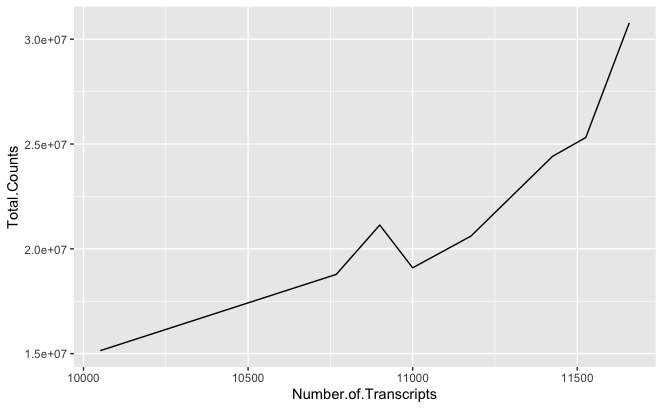

```r
ggplot(data=data, mapping= aes(x=Number.of.Transcripts, y = Total.Counts)) +
        geom_line()
```

Regresemos al gráfico de puntos, podemos visualizar cómo se comporta dado el tratamiento.

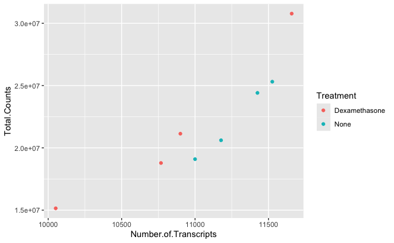

```r
ggplot(data=data, mapping= aes(x=Number.of.Transcripts, y = Total.Counts, color=Treatment)) +         geom_point()
```

ggplot2 asignará automáticamente colores a las categorías de nuestros datos. Podemos cambiar los colores predeterminados aportando una capa adicional a nuestra figura. Para cambiar el color, usamos las funciones scale_color: scale_color_manual(), scale_color_brewer(), scale_color_grey(), etc. También podemos cambiar el nombre de las etiquetas de color en la leyenda usando el argumento de etiquetas de estas funciones.

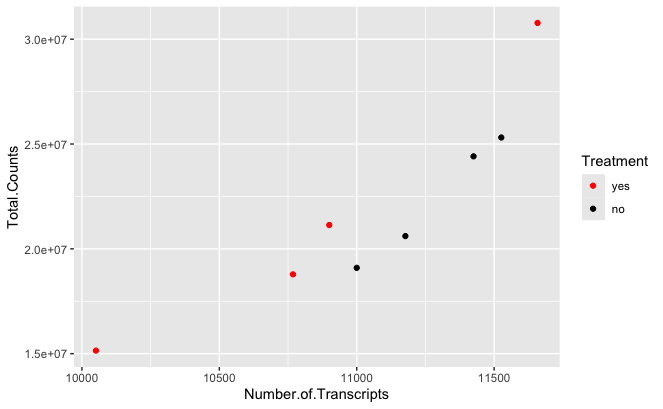

```r
ggplot(data=data, mapping= aes(x=Number.of.Transcripts, y = Total.Counts, color=Treatment)) +         geom_point() +
        scale_color_manual(values=c("red","black"), labels=c('yes','no'))
```

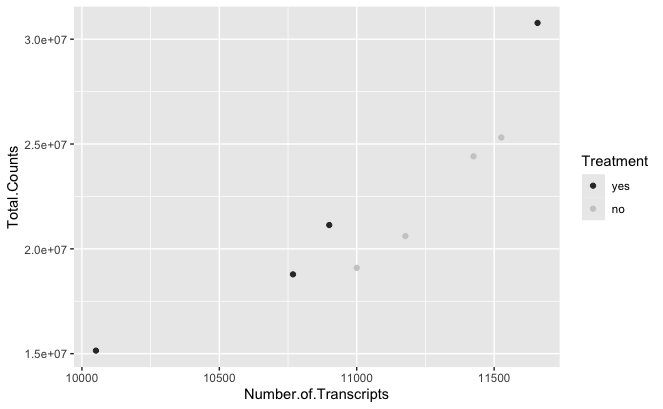

```r
ggplot(data=data, mapping= aes(x=Number.of.Transcripts, y = Total.Counts, color=Treatment)) +         geom_point() +
        scale_color_grey(labels=c('yes','no'))
```

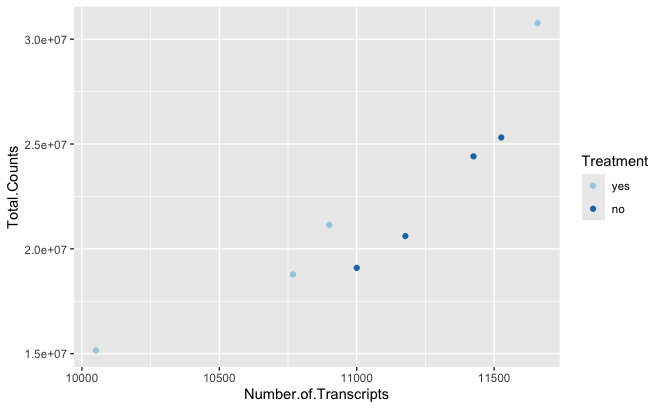

```r
ggplot(data=data, mapping= aes(x=Number.of.Transcripts, y = Total.Counts, color=Treatment)) +         geom_point() +
        scale_color_brewer(palette ="Paired", labels=c('yes','no'))
```

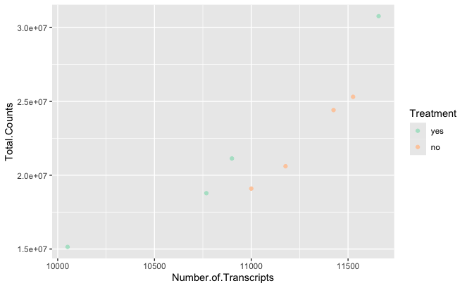

```r
ggplot(data=data, mapping= aes(x=Number.of.Transcripts, y = Total.Counts, color=Treatment)) +         geom_point() +
        scale_color_brewer(palette ="Pastel2", labels=c('yes','no'))
```

Para las opciones de palette revisar la sección de palettes de la función scale_color_brewer().

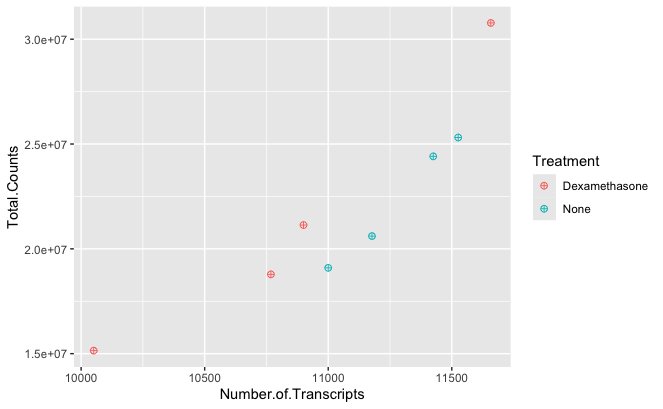

```r
ggplot(data=data, mapping= aes(x=Number.of.Transcripts, y = Total.Counts, color=Treatment))  +        geom_point(shape=10, size=2)
```

```r
NA
```

Otras formas:

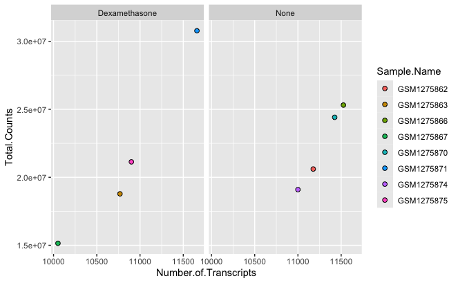

```r
ggplot(data=data) +
  geom_point(aes(x=Number.of.Transcripts, y = Total.Counts,fill=Sample.Name),
             shape=21,size=2) +
    facet_wrap(~Treatment)
```

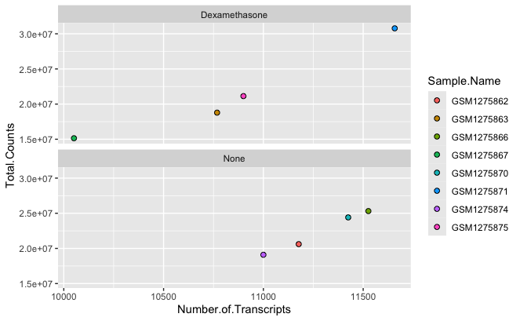

```r
ggplot(data=data) +
  geom_point(aes(x=Number.of.Transcripts, y = Total.Counts,fill=Sample.Name),
             shape=21,size=2) +
  facet_wrap(~Treatment, ncol=1)
```

Uso de múltiples geoms

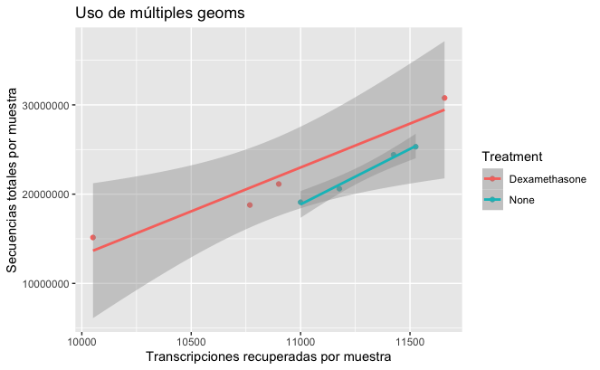

```r
ggplot(data=data, mapping=aes(x=Number.of.Transcripts, y = Total.Counts, color=Treatment)) +
  geom_point() +
  geom_smooth(method='lm', aes(x=Number.of.Transcripts, y = Total.Counts, color= Treatment)) +
  labs(title = "Uso de múltiples geoms") +
  xlab("Transcripciones recuperadas por muestra")+
  ylab("Secuencias totales por muestra") +
  scale_y_continuous(labels = function(x) format(x, scientific = FALSE))
```

```r
ggplot(data=data, aes(x=Number.of.Transcripts, y = Total.Counts, color=Treatment)) +
  geom_point() +
  geom_smooth(method='lm') +
  xlab("Transcripciones recuperadas por muestra")+
  ylab("Secuencias totales por muestra") +
  scale_y_continuous(labels = function(x) format(x, scientific = FALSE))
```

[output not shown]

Para guardar nuestro gráfico en un archivo, la forma más sencilla de hacer esto con ggplot2 es usando la función ggsave(). Esta función guardará el último gráfico que mostró de forma predeterminada.

```r
ggsave("prueba.png")
```

```r
p = ggplot(data=data, aes(x=Number.of.Transcripts, y = Total.Counts, color=Treatment)) +
  geom_point() +
  geom_smooth(method='lm') +
  xlab("Transcripciones recuperadas por muestra")+
  ylab("Secuencias totales por muestra") +
  scale_y_continuous(labels = function(x) format(x, scientific = FALSE))
```

Otra forma es usando las funciones pdf, png, ps, jpeg

```r
pdf("mi_plot.pdf",         # Nombre del archivo
    width = 8, height = 7, # Ancho y alto en pulgadas
    bg = "white"       # Color de fondo
 )
p
dev.off()
```

```r
png("miplot.png", width=1200, height=1000, units="px")
p
dev.off()
```

```r
jpeg("miplot.jpeg", quality=75)
p
dev.off()
```

```r
jpeg("miplot.jpeg", quality=75, width= 1200, height=1000)
p
dev.off()
```